# Lab 9 - Solutions

Carl Gladish

Nov 7, 2025

## Question 1

The function `NormalMeans` simulates `m.trials` instances of $\overline{X}$ for samples of size `n.sample` (taken from a standard normal distribution) and generates the mean, the standard deviation, and a histogram of $\overline{X}$.

```r
NormalMeans <- function(m.trials, n.sample){
  mu <- 0
  sigma <- 1
  Xbar.vals <- double(m.trials)

  for (i in 1:m.trials){
    Xbar.vals[i] <- mean(rnorm(n.sample, mean=mu, sd=sigma))
  }

  mu_Xbar <- mean(Xbar.vals)
  sig_Xbar <- sd(Xbar.vals)

  print(paste0("n = ", n.sample,
               ", mu_Xbar = ", sprintf("%.4f", mu_Xbar),
              ", sig_Xbar = ", sprintf("%.4f", sig_Xbar)))

  histogram(Xbar.vals, type="density", col="lightblue",
       xlab="Xbar", ylab="prob. density", breaks=50,
       xlim=c(-4, 4),
       main=paste0("Xbar (n =", n.sample, ")"))
}
```

#### Sample size $n=1$.

```r
NormalMeans(10^5, 1)
```

```
## [1] "n = 1, mu_Xbar = 0.0032, sig_Xbar = 1.0000"
```

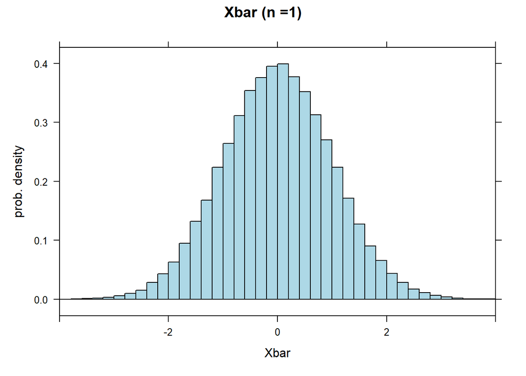

#### Sample size $n=2$.

```r
NormalMeans(10^5, 2)
```

```
## [1] "n = 2, mu_Xbar = 0.0019, sig_Xbar = 0.7053"
```

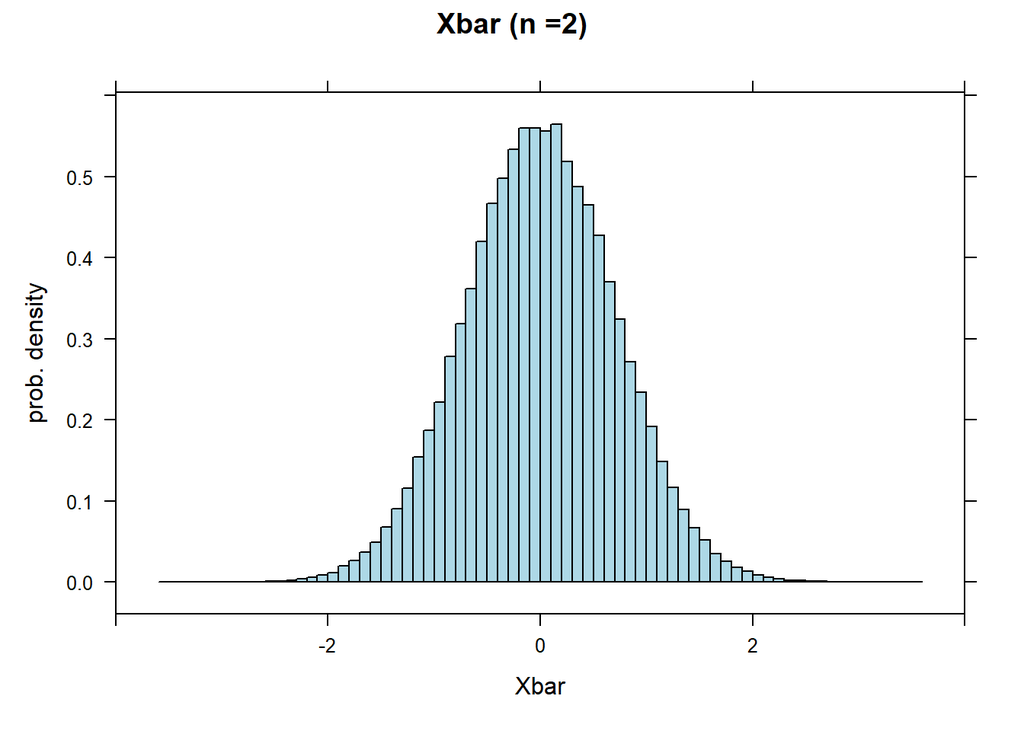

#### Sample size $n=10$.

```r
NormalMeans(10^5, 10)
```

```
## [1] "n = 10, mu_Xbar = -0.0005, sig_Xbar = 0.3163"
```

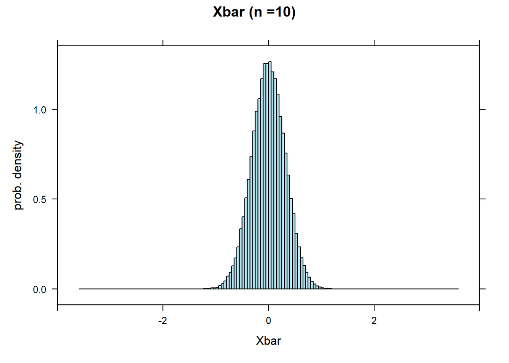

#### Sample size $n=50$.

```r
NormalMeans(10^5, 50)
```

```
## [1] "n = 50, mu_Xbar = -0.0002, sig_Xbar = 0.1416"
```

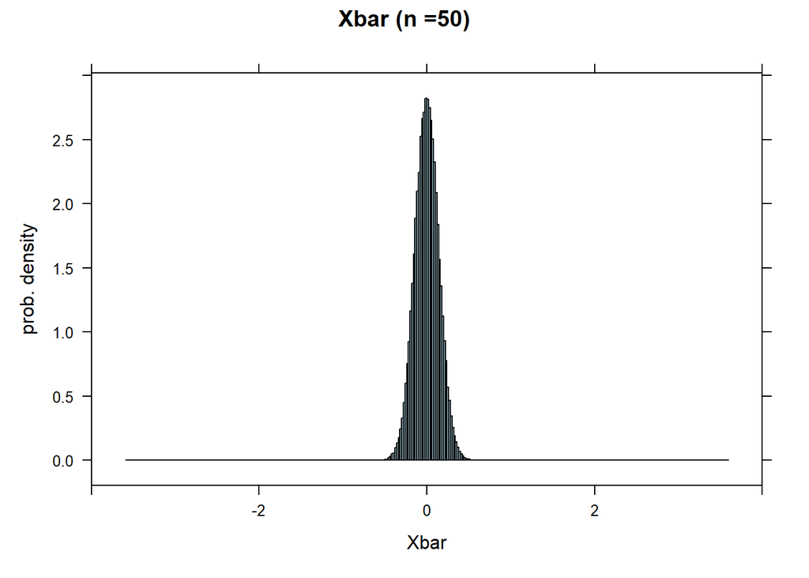

#### Sample size $n=100$.

```r
NormalMeans(10^5, 100)
```

```
## [1] "n = 100, mu_Xbar = 0.0002, sig_Xbar = 0.1004"
```

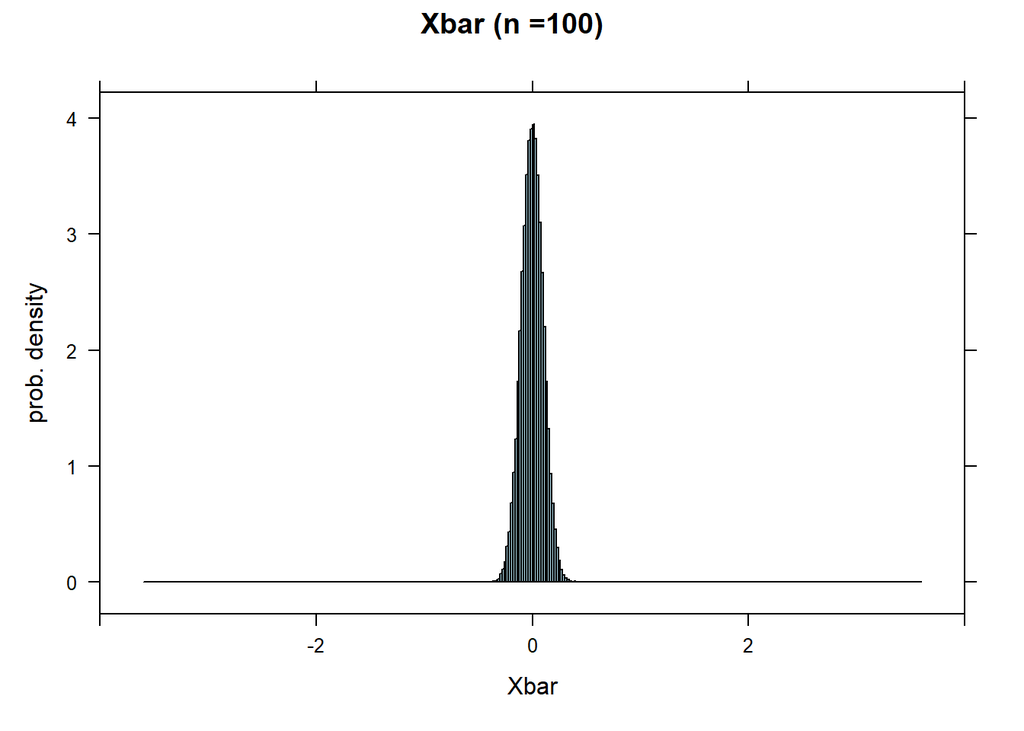

The distribution of $\overline{X}$ is normal for all $n$. As the sample size $n$ increases, the mean value $\mu_\overline{X}$ remains constant around $0.0$ but the standard deviation $\sigma_\overline{X}$ decreases from $1.0$ for $n=1$ to $0.1$ for $n=100$. Correspondingly, the histogram remains centered at $0$ but it becomes narrower and taller.

## Question 2

The function `ExponentialMeans` simulates `m.trials` instances of $\overline{X}$ for samples of size `n.sample` (taken from an exponential distribution with $\beta=1$) and generates the mean, the standard deviation, and a histogram of $\overline{X}$.

```r
ExponentialMeans <- function(m.trials, n.sample){
  beta <- 1
  Xbar.vals <- double(m.trials)

  for (i in 1:m.trials){
    Xbar.vals[i] <- mean(rexp(n.sample, rate=1/beta))
  }

  mu_Xbar <- mean(Xbar.vals)
  sig_Xbar <- sd(Xbar.vals)

 print(paste0("n = ", n.sample,
              ", mu_Xbar = ", sprintf("%.4f", mu_Xbar),
              ", sig_Xbar = ", sprintf("%.4f", sig_Xbar)))

 histogram(Xbar.vals, type="density", col="lightblue",
       xlab="Xbar", ylab="prob. density", breaks=50,
       xlim=c(-1, 6),
       main=paste0("Xbar (n =", n.sample, "), X ~ Exp(1)"))
}
```

#### Sample size $n=1$

```r
ExponentialMeans(10^5, 1)
```

```
## [1] "n = 1, mu_Xbar = 1.0028, sig_Xbar = 1.0007"
```

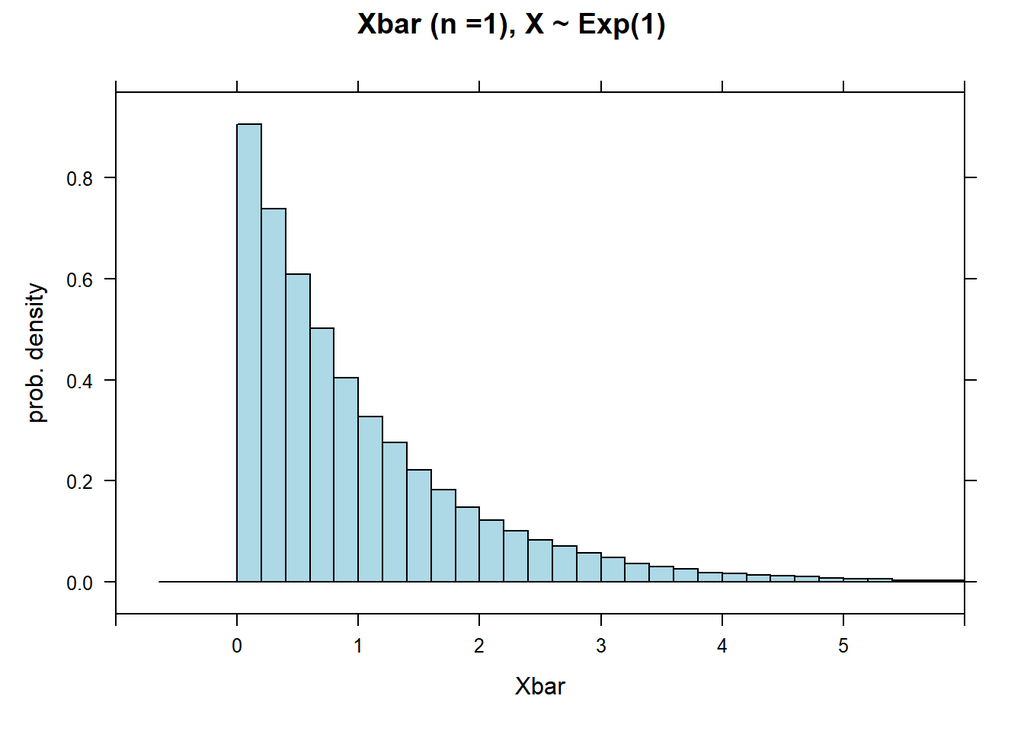

#### Sample size $n=2$

```r
ExponentialMeans(10^5, 2)
```

```
## [1] "n = 2, mu_Xbar = 1.0018, sig_Xbar = 0.7058"
```

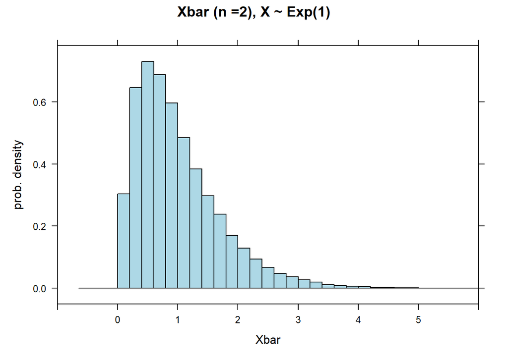

#### Sample size $n=10$

```r
ExponentialMeans(10^5, 10)
```

```
## [1] "n = 10, mu_Xbar = 1.0000, sig_Xbar = 0.3163"
```

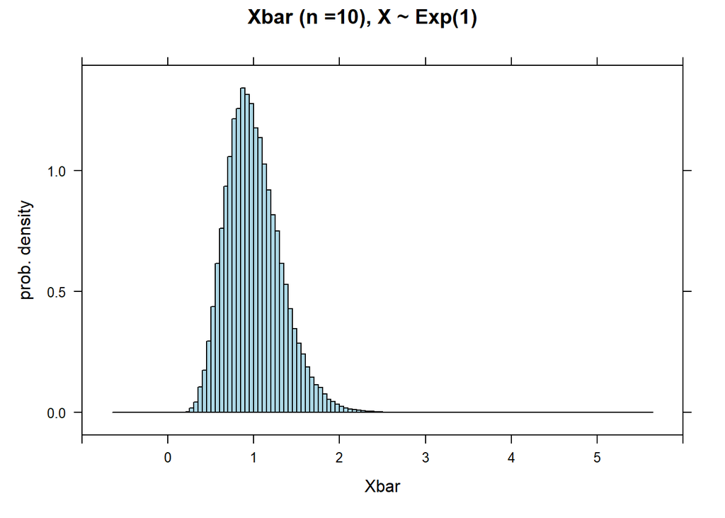

#### Sample size $n=50$

```r
ExponentialMeans(10^5, 50)
```

```
## [1] "n = 50, mu_Xbar = 0.9997, sig_Xbar = 0.1410"
```

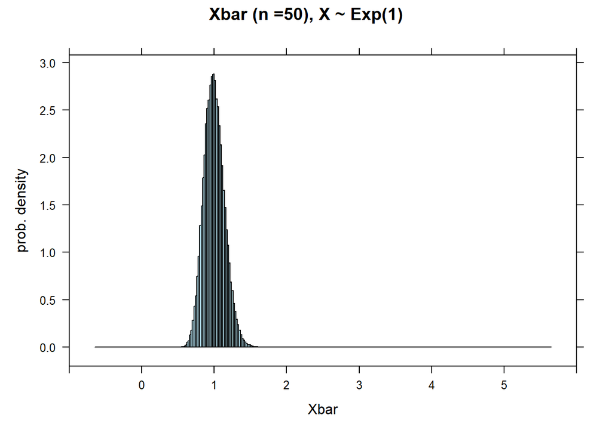

#### Sample size $n=100$

```r
ExponentialMeans(10^5, 100)
```

```
## [1] "n = 100, mu_Xbar = 0.9998, sig_Xbar = 0.1001"
```

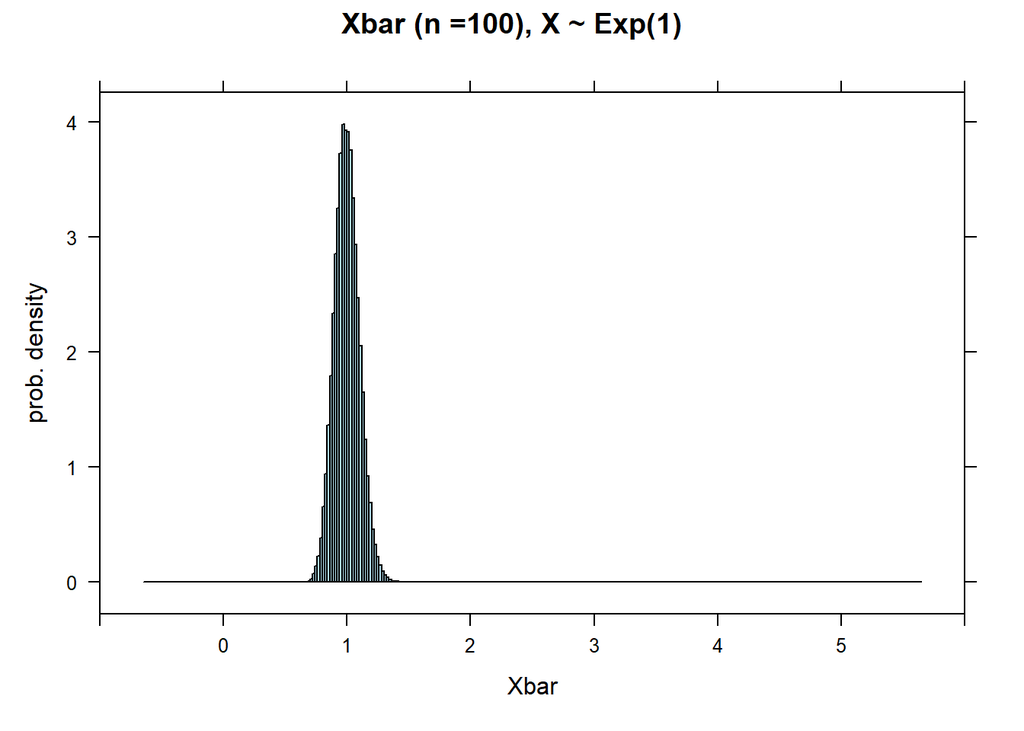

The mean value of $\overline{X}$ remains $\approx 1.0$ for all sample sizes. However, the standard deviation decreases from $\sigma_\overline{X} = 1.0$ for $n=1$ to $\sigma_\overline{X}=0.1$ for $n=100$.

The shape of the sampling distribution of $\overline{X}$ changes as $n$ increases. For $n=1$ the shape is just the original exponential distribution. As $n$ increases the shape gradually becomes closer to being normal. For $n=50$ (and larger) the shape is definitely normal.

## Question 3

```r
ExponentialMeansProb <- function(m.trials, beta, n.sample, z){

  Xbar.vals <- double(m.trials)

  for (i in 1:m.trials){
    Xbar.vals[i] <- mean(rexp(n.sample, rate=1/beta))
  }

  k.success <- sum( (Xbar.vals > (beta - z*beta/sqrt(n.sample))) &
                    (Xbar.vals < (beta + z*beta/sqrt(n.sample))) )

  return( k.success / m.trials )
}
```

```r
p1 <- ExponentialMeansProb(10^5, 1, 1, 1)
p2 <- ExponentialMeansProb(10^5, 1, 1, 2)
p3 <- ExponentialMeansProb(10^5, 1, 1, 3)
p4 <- ExponentialMeansProb(10^5, 1, 5, 1)
p5 <- ExponentialMeansProb(10^5, 1, 5, 2)
p6 <- ExponentialMeansProb(10^5, 1, 5, 3)
p7 <- ExponentialMeansProb(10^5, 1, 50, 1)
p8 <- ExponentialMeansProb(10^5, 1, 50, 2)
p9 <- ExponentialMeansProb(10^5, 1, 50, 3)
```

|  | $z=1$ | $z=2$ | $z=3$ |
| --- | --- | --- | --- |
| `n.sample` $=1$ | 0.86548 | 0.94992 | 0.98202 |
| `n.sample` $=5$ | 0.7019 | 0.95841 | 0.99037 |
| `n.sample` $=50$ | 0.68324 | 0.95545 | 0.99642 |

The probabilities from the Empirical Rule would be: 68%, 95%, 99.7%.

For $n = 1$, the probabilities differ quite a lot from the 68-96-99.7 rule, especially for $z=1$.

For $n=50$ the probabilities agree quite well with the 68-95-99.7 rule.

## Question 4

Load the `genotype` data set.

```r
data(genotype)
```

Filter the genotype data according to the “Litter” (A, B, I, or J).

```r
group.A <- filter(genotype, Litter=="A")
group.B <- filter(genotype, Litter=="B")
group.I <- filter(genotype, Litter=="I")
group.J <- filter(genotype, Litter=="J")
```

Generate QQ plots for each group.

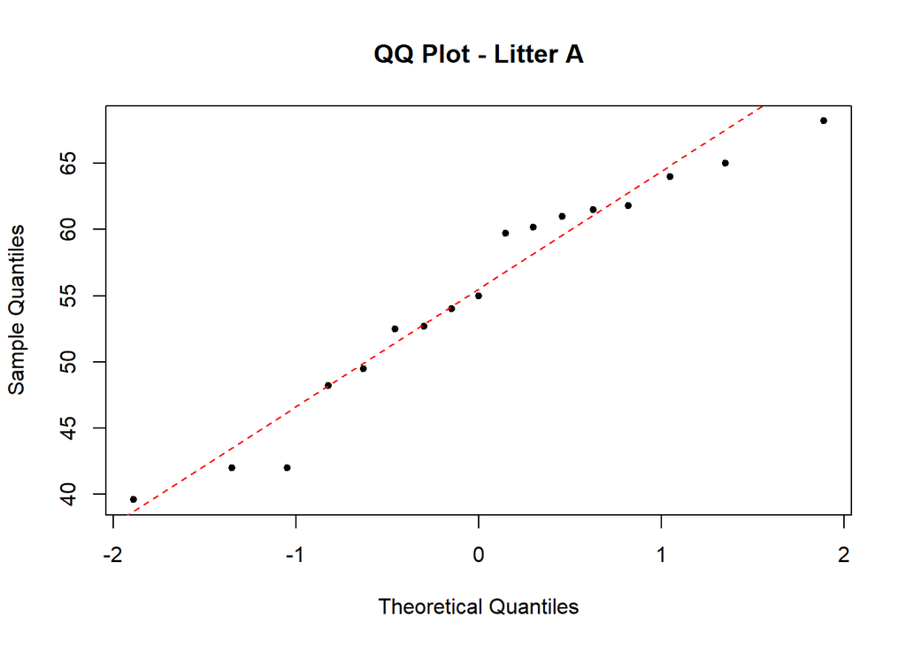

```r
qqnorm(group.A$Wt, main="QQ Plot - Litter A",pch=20)
qqline(group.A$Wt, col="red", lty="dashed")
```

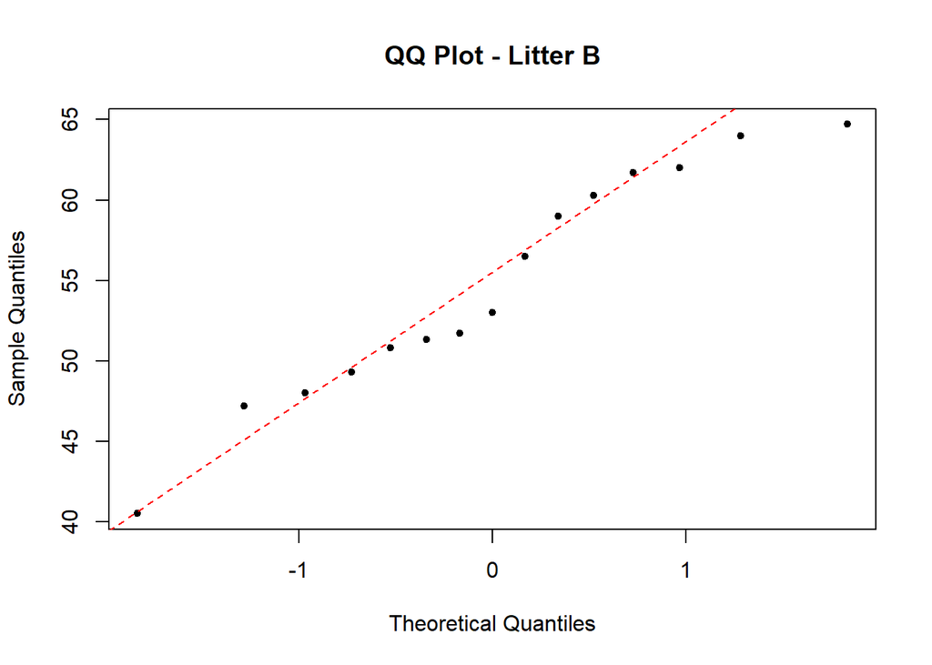

```r
qqnorm(group.B$Wt, main="QQ Plot - Litter B",pch=20)
qqline(group.B$Wt, col="red", lty="dashed")
```

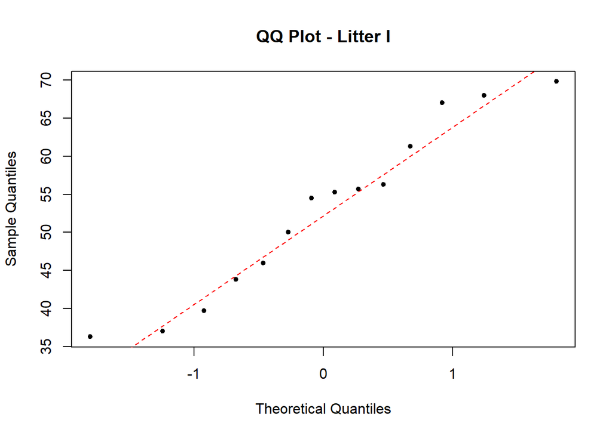

```r
qqnorm(group.I$Wt, main="QQ Plot - Litter I",pch=20)
qqline(group.I$Wt, col="red", lty="dashed")
```

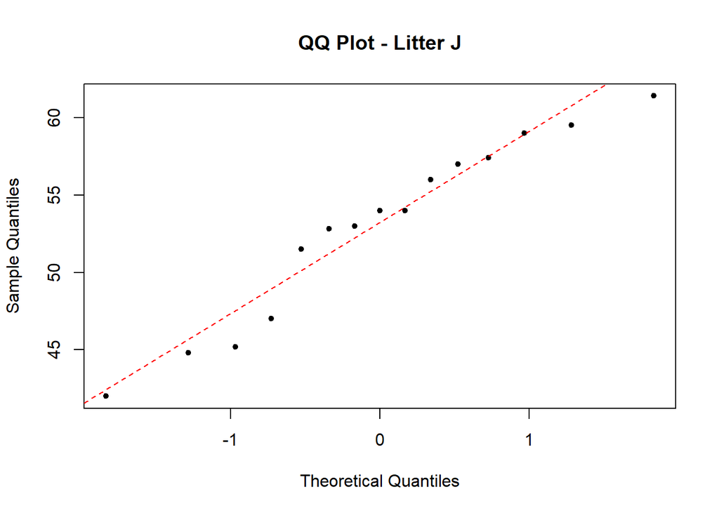

```r
qqnorm(group.J$Wt, main="QQ Plot - Litter J",pch=20)
qqline(group.J$Wt, col="red", lty="dashed")
```

All four QQ plots show approximately a straight line. (At least, the deviations from a straight line appear to be random as opposed to *systematic* in any way.) Therefore each “Litter” appears to be a sample from a normal distribution.